# assignment

2025-03-16

## Preparation steps

```r
suppressPackageStartupMessages({
  library(AnnotationHub)
  library(rtracklayer)
  library(epiwraps)
  library(GenomicRanges)
})
if (!requireNamespace("R.utils", quietly = TRUE)) {
  install.packages("R.utils")
}
library(R.utils)
```

```r
library(ggplot2)
```

## Downloading the data

Downloading peak data from ENCODE for p300, H3K4me3, H3K4me1, H3K27ac and H3K27me3 in the mouse embryonic stem cell line Bruce 4 and unzipping it

```r
#download the peaks (always as bed narrowPeak)
options(timeout=3600)


download.file("https://www.encodeproject.org/files/ENCFF460EOA/@@download/ENCFF460EOA.bed.gz", "P300_peaks.bed.gz") #conservative IDR threshold peaks
download.file("https://www.encodeproject.org/files/ENCFF247GVM/@@download/ENCFF247GVM.bed.gz", "H3K4me3_peaks.bed.gz") #replicated peaks
download.file("https://www.encodeproject.org/files/ENCFF824AFZ/@@download/ENCFF824AFZ.bed.gz", "H3K4me1_peaks.bed.gz") #pseudoreplicated peaks
download.file("https://www.encodeproject.org/files/ENCFF360VIS/@@download/ENCFF360VIS.bed.gz", "H3K27ac_peaks.bed.gz") #pseudoreplicated peaks
download.file("https://www.encodeproject.org/files/ENCFF105NKG/@@download/ENCFF105NKG.bed.gz", "H3K27me3_peaks.bed.gz")


# Unzip the BED files
gunzip("P300_peaks.bed.gz")
gunzip("H3K4me3_peaks.bed.gz")
gunzip("H3K4me1_peaks.bed.gz")
gunzip("H3K27ac_peaks.bed.gz")
gunzip("H3K27me3_peaks.bed.gz")
```

## Converting the BED-files to GRanges objects

1. P300

```r
#Look at the BED-file
bed_file <- read.table("P300_peaks.bed", header = FALSE, nrows = 10)
print(bed_file)
```

```
##       V1        V2        V3 V4   V5 V6       V7 V8      V9 V10
## 1   chr5  64864674  64865203  . 1000  . 396.1237 -1 4.18398 231
## 2  chr12 110472274 110472558  . 1000  . 391.3697 -1 4.18398 155
## 3   chr5 134970647 134970959  . 1000  . 360.3133 -1 4.18398 175
## 4  chr17  35503880  35504190  . 1000  . 360.0738 -1 4.18398 150
## 5   chr3  34757793  34758086  . 1000  . 358.9863 -1 4.18398 133
## 6  chr10  85539868  85540221  . 1000  . 354.4610 -1 4.18398 201
## 7   chr2  30779268  30779644  . 1000  . 343.3472 -1 4.18398 154
## 8   chr6 149131211 149131481  . 1000  . 339.9960 -1 4.18398 130
## 9   chr8  36549128  36549467  . 1000  . 333.6919 -1 4.18398 188
## 10 chr10  70359504  70359735  . 1000  . 333.0320 -1 4.18398  99
```

```r
# FOR P300: Import BED files as GRanges objects

# Keep only the first three columns (chromosome, start, end) and assign appropriate names
p300_peaks <- read.table("P300_peaks.bed", header = FALSE)[, 1:3]
colnames(p300_peaks) <- c("chr", "start", "end")

# Convert to GRanges object
p300_peaks_gr <- GRanges(
  seqnames = p300_peaks$chr,
  ranges = IRanges(start = p300_peaks$start, end = p300_peaks$end)
)

# Inspect the GRanges object
p300_peaks_gr
```

```
## GRanges object with 28341 ranges and 0 metadata columns:
##           seqnames              ranges strand
##              <Rle>           <IRanges>  <Rle>
##       [1]     chr5   64864674-64865203      *
##       [2]    chr12 110472274-110472558      *
##       [3]     chr5 134970647-134970959      *
##       [4]    chr17   35503880-35504190      *
##       [5]     chr3   34757793-34758086      *
##       ...      ...                 ...    ...
##   [28337]    chr12   70226986-70227266      *
##   [28338]     chr1 132357602-132357882      *
##   [28339]     chr2 167431909-167432189      *
##   [28340]    chr13 119791154-119791434      *
##   [28341]    chr14   75855557-75855837      *
##   -------
##   seqinfo: 20 sequences from an unspecified genome; no seqlengths
```

2. H3K4me3

```r
# Repeat for H3K4me3

#Look at the BED-file
bed_file <- read.table("H3K4me3_peaks.bed", header = FALSE, nrows = 10)
print(bed_file)
```

```
##       V1        V2        V3         V4  V5 V6       V7        V8        V9 V10
## 1  chr10 100015390 100015755 Peak_13247 231  . 22.07147 113.69553 110.76782 186
## 2  chr10 100015800 100016738 Peak_12266 250  . 21.26603 123.25237 120.26219 173
## 3  chr10  10017877  10018323 Peak_37546  32  .  6.14210  13.58947  11.40160 127
## 4  chr10 100486592 100487335  Peak_7910 353  . 25.40144 174.97375 171.62355 574
## 5  chr10 100487591 100487953 Peak_14027 215  . 13.58112 105.48596 102.61023 170
## 6  chr10 100588589 100589259  Peak_1178 601  . 39.76157 299.65805 295.11951 527
## 7  chr10 102323864 102324071 Peak_42667  25  .  6.00835  10.00590   7.87378 102
## 8  chr10 102433074 102433347 Peak_31202  48  . 10.12347  21.27859  18.99849 179
## 9  chr10 103027945 103028834 Peak_23452  88  . 11.13573  41.69542  39.23839 503
## 10 chr10 103028925 103029118 Peak_30266  51  .  6.92294  22.98327  20.68509  98
```

```r
# Read the BED file and keep only the first three columns (chromosome, start, end) and assign appropriate names
H3K4me3_peaks <- read.table("H3K4me3_peaks.bed", header = FALSE)[, 1:3]
colnames(H3K4me3_peaks) <- c("chr", "start", "end")

# Convert to GRanges object
H3K4me3_peaks_gr <- GRanges(
  seqnames = H3K4me3_peaks$chr,
  ranges = IRanges(start = H3K4me3_peaks$start, end = H3K4me3_peaks$end)
)

# Inspect the GRanges object
H3K4me3_peaks_gr
```

```
## GRanges object with 52499 ranges and 0 metadata columns:
##                       seqnames              ranges strand
##                          <Rle>           <IRanges>  <Rle>
##       [1]                chr10 100015390-100015755      *
##       [2]                chr10 100015800-100016738      *
##       [3]                chr10   10017877-10018323      *
##       [4]                chr10 100486592-100487335      *
##       [5]                chr10 100487591-100487953      *
##       ...                  ...                 ...    ...
##   [52495] chrX_GL456233_random       159675-159895      *
##   [52496] chrX_GL456233_random         38713-39228      *
##   [52497]                 chrY     1010645-1010833      *
##   [52498]                 chrY     1245235-1245626      *
##   [52499]                 chrY       809264-809418      *
##   -------
##   seqinfo: 27 sequences from an unspecified genome; no seqlengths
```

3. H3K4me1

```r
# Repeat for H3K4me1

#Look at the BED-file
bed_file <- read.table("H3K4me1_peaks.bed", header = FALSE, nrows = 10)
print(bed_file)
```

```
##       V1        V2        V3      V4   V5 V6       V7       V8       V9 V10
## 1  chr18  49771039  49771301  Peak_1 1000  . 19.21178 60.30239 51.34408 120
## 2   chr6  94749915  94750116  Peak_2  991  . 16.08870 59.85002 51.11356 101
## 3   chr9 108586875 108587343  Peak_3  950  . 13.45416 57.43179 49.22681 211
## 4  chr19   5060211   5060910  Peak_4  882  .  8.29387 53.42401 45.73677 405
## 5   chr5  30416929  30417123  Peak_5  879  . 13.54591 53.22132 45.54932 104
## 6   chr7  27498512  27498725  Peak_6  865  .  8.20660 52.46438 44.86146 105
## 7  chr19   5811700   5812084  Peak_7  789  .  9.36424 47.97985 40.79239 224
## 8   chr7  90023505  90023748  Peak_8  780  . 16.01204 47.49498 40.33134 103
## 9   chr3 101633310 101633525  Peak_9  760  . 15.35927 46.26087 39.18905 106
## 10 chr15   7530517   7531021 Peak_10  752  . 15.08199 45.72938 38.72692 401
```

```r
# Read the BED file and keep only the first three columns (chromosome, start, end) and assign appropriate names
H3K4me1_peaks <- read.table("H3K4me1_peaks.bed", header = FALSE)[, 1:3]
colnames(H3K4me1_peaks) <- c("chr", "start", "end")

# Convert to GRanges object
H3K4me1_peaks_gr <- GRanges(
  seqnames = H3K4me1_peaks$chr,
  ranges = IRanges(start = H3K4me1_peaks$start, end = H3K4me1_peaks$end)
)

# Inspect the GRanges object
H3K4me1_peaks_gr
```

```
## GRanges object with 146024 ranges and 0 metadata columns:
##            seqnames              ranges strand
##               <Rle>           <IRanges>  <Rle>
##        [1]    chr18   49771039-49771301      *
##        [2]     chr6   94749915-94750116      *
##        [3]     chr9 108586875-108587343      *
##        [4]    chr19     5060211-5060910      *
##        [5]     chr5   30416929-30417123      *
##        ...      ...                 ...    ...
##   [146020]     chr8   70809880-70810040      *
##   [146021]     chr9 110813906-110814200      *
##   [146022]     chr9 119100174-119100515      *
##   [146023]     chr9   20991351-20991515      *
##   [146024]     chr9   21566804-21567031      *
##   -------
##   seqinfo: 22 sequences from an unspecified genome; no seqlengths
```

4. H3K27ac

```r
# Repeat for H3K27ac

#Look at the BED-file
bed_file <- read.table("H3K27ac_peaks.bed", header = FALSE, nrows = 10)
print(bed_file)
```

```
##       V1        V2        V3         V4  V5 V6       V7       V8       V9 V10
## 1  chr10 100065742 100066128 Peak_35036  29  .  5.87555  9.19366  6.85029 212
## 2  chr10 100066318 100066680 Peak_55975  19  .  4.19685  5.69524  3.53494 281
## 3  chr10 100163866 100164344 Peak_20399  48  .  8.39369 16.14233 13.55909 274
## 4  chr10 100164566 100165264 Peak_24148  41  .  7.68341 13.62456 11.11811 531
## 5  chr10 100567649 100567858 Peak_48526  22  .  4.61653  6.60090  4.38649 147
## 6  chr10 101166668 101166970 Peak_26303  38  .  7.23145 12.47599 10.00780 102
## 7  chr10 102370341 102370703 Peak_39803  26  .  5.42359  8.16031  5.86739 132
## 8  chr10 103344791 103345289 Peak_55502  19  .  3.90356  5.70470  3.54184 174
## 9  chr10 103346029 103346613 Peak_21967  44  .  7.15654 14.94036 12.39103 336
## 10 chr10 103347079 103347461  Peak_6601 116  . 11.66742 41.36726 38.23030 138
```

```r
# Read the BED file and keep only the first three columns (chromosome, start, end) and assign appropriate names
H3K27ac_peaks <- read.table("H3K27ac_peaks.bed", header = FALSE)[, 1:3]
colnames(H3K27ac_peaks) <- c("chr", "start", "end")

# Convert to GRanges object
H3K27ac_peaks_gr <- GRanges(
  seqnames = H3K27ac_peaks$chr,
  ranges = IRanges(start = H3K27ac_peaks$start, end = H3K27ac_peaks$end)
)

# Inspect the GRanges object
H3K27ac_peaks_gr
```

```
## GRanges object with 53802 ranges and 0 metadata columns:
##           seqnames              ranges strand
##              <Rle>           <IRanges>  <Rle>
##       [1]    chr10 100065742-100066128      *
##       [2]    chr10 100066318-100066680      *
##       [3]    chr10 100163866-100164344      *
##       [4]    chr10 100164566-100165264      *
##       [5]    chr10 100567649-100567858      *
##       ...      ...                 ...    ...
##   [53798]     chrY   90732101-90732421      *
##   [53799]     chrY   90733743-90733931      *
##   [53800]     chrY   90735600-90735865      *
##   [53801]     chrY   90737498-90737700      *
##   [53802]     chrY   90738065-90739582      *
##   -------
##   seqinfo: 27 sequences from an unspecified genome; no seqlengths
```

5. H3K27me3

```r
# Repeat for H3K27me3

#Look at the BED-file
bed_file <- read.table("H3K27me3_peaks.bed", header = FALSE, nrows = 10)
print(bed_file)
```

```
##      V1        V2        V3         V4  V5 V6      V7       V8      V9 V10
## 1  chr1  10231460  10231706 Peak_13046  57  . 4.24990  5.77807 2.41723  96
## 2  chr1 104767879 104768250 Peak_19149  50  . 3.67759  5.09833 1.89336 278
## 3  chr1 104769962 104770266 Peak_16177  56  . 3.99687  5.61519 2.31307  82
## 4  chr1 104993516 104993656  Peak_6089  76  . 4.54586  7.62347 3.89459  52
## 5  chr1 104994057 104994548   Peak_852 130  . 5.23117 13.05543 8.34427 148
## 6  chr1 105892659 105892781  Peak_6196  75  . 4.68057  7.55663 3.83925  37
## 7  chr1 105988812 105988949 Peak_18724  52  . 3.74363  5.20593 1.98727  40
## 8  chr1 106713379 106713952  Peak_5240  78  . 4.83673  7.82011 4.03401 158
## 9  chr1 106714256 106714387 Peak_10211  64  . 3.89889  6.45269 2.96426  54
## 10 chr1  10993515  10993922 Peak_25106  48  . 2.63528  4.86682 1.73647 320
```

```r
# Read the BED file and keep only the first three columns (chromosome, start, end) and assign appropriate names
H3K27me3_peaks <- read.table("H3K27me3_peaks.bed", header = FALSE)[, 1:3]
colnames(H3K27me3_peaks) <- c("chr", "start", "end")

# Convert to GRanges object
H3K27me3_peaks_gr <- GRanges(
  seqnames = H3K27me3_peaks$chr,
  ranges = IRanges(start = H3K27me3_peaks$start, end = H3K27me3_peaks$end)
)

# Inspect the GRanges object
H3K27me3_peaks_gr
```

```
## GRanges object with 11472 ranges and 0 metadata columns:
##           seqnames              ranges strand
##              <Rle>           <IRanges>  <Rle>
##       [1]     chr1   10231460-10231706      *
##       [2]     chr1 104767879-104768250      *
##       [3]     chr1 104769962-104770266      *
##       [4]     chr1 104993516-104993656      *
##       [5]     chr1 104994057-104994548      *
##       ...      ...                 ...    ...
##   [11468]     chrX   99561812-99561953      *
##   [11469]     chrX   99564039-99564314      *
##   [11470]     chrX   99820954-99821107      *
##   [11471]     chrX   99821511-99821990      *
##   [11472]     chrX   99822206-99822355      *
##   -------
##   seqinfo: 20 sequences from an unspecified genome; no seqlengths
```

## Finding the overlaps between p300 and the four Histone marks

1. H3K4me3

```r
# Find overlaps between p300 and H3K4me3
overlap_H3K4me3 <- findOverlaps(H3K4me3_peaks_gr, p300_peaks_gr) # to find all the overlapping regions, chose "any" as lose quite a lot with "within"

# Calculate percentage of p300 peaks that overlap with H3K4me3
percentage_H3K4me3 <- length(unique(subjectHits(overlap_H3K4me3))) / length(p300_peaks_gr)*100
percentage_H3K4me3
```

```
## [1] 36.52306
```

```r
cat("Proportion of P300 peaks that overlap H3K4me3:", percentage_H3K4me3, "%\n")
```

```
## Proportion of P300 peaks that overlap H3K4me3: 36.52306 %
```

2. H3K4me1

```r
# Find overlaps between p300 and H3K4me1
overlap_H3K4me1 <- findOverlaps(H3K4me1_peaks_gr, p300_peaks_gr)

# Calculate percentage of p300 peaks that overlap with H3K4me1
percentage_H3K4me1 <- length(unique(subjectHits(overlap_H3K4me1))) / length(p300_peaks_gr)*100
percentage_H3K4me1
```

```
## [1] 37.47574
```

```r
cat("Proportion of P300 peaks that overlap H3K4me1:", percentage_H3K4me1, "%\n")
```

```
## Proportion of P300 peaks that overlap H3K4me1: 37.47574 %
```

3. H3K27ac

```r
# Find overlaps between p300 and H3K27ac
overlap_H3K27ac <- findOverlaps(H3K27ac_peaks_gr, p300_peaks_gr)

# Calculate percentage of p300 peaks that overlap with H3K27ac
percentage_H3K27ac <- length(unique(subjectHits(overlap_H3K27ac))) / length(p300_peaks_gr)*100
percentage_H3K27ac
```

```
## [1] 52.54578
```

```r
cat("Proportion of P300 peaks that overlap H3K27ac:", percentage_H3K27ac, "%\n")
```

```
## Proportion of P300 peaks that overlap H3K27ac: 52.54578 %
```

4. H3K27me3

```r
# Find overlaps between p300 and H3K27me3
overlap_H3K27me3 <- findOverlaps(H3K27me3_peaks_gr, p300_peaks_gr)

# Calculate percentage of p300 peaks that overlap with H3K27me3
percentage_H3K27me3 <- length(unique(subjectHits(overlap_H3K27me3))) / length(p300_peaks_gr)*100
percentage_H3K27me3
```

```
## [1] 0.2575774
```

```r
cat("Proportion of P300 peaks that overlap H3K27me3:", percentage_H3K27me3, "%\n")
```

```
## Proportion of P300 peaks that overlap H3K27me3: 0.2575774 %
```

## Find more relevant overlaps

Alternatively, we could maybe try and exclude less relevant overlaps by setting a minimum overlap-length.

1. p300 and H3K4me3

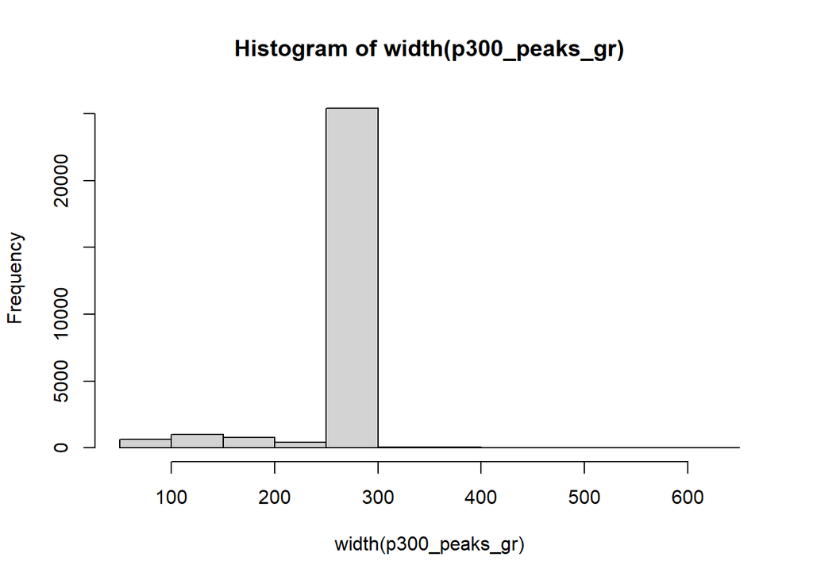

```r
# Find overlaps between p300 and H3K4me3
hist(width(p300_peaks_gr))
```

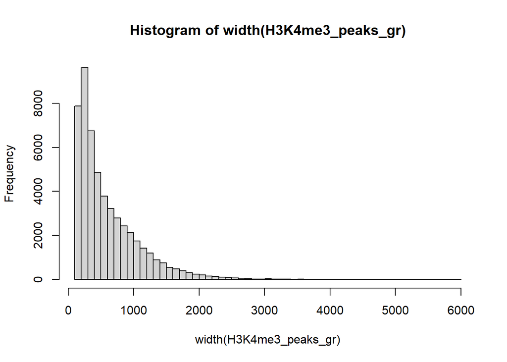

```r
hist(width(H3K4me3_peaks_gr), breaks=75)
```

The two histograms show p300 has average length of 300bp and for H3K4me3 most reads are ca 200bp long, but up to 2000bp. We could specify the lengths of the overlaps to just include overlaps of a minimum of 50bp to get more meaningful overlaps.

```r
# Find overlaps between p300 and H3K4me3
overlap_H3K4me3_min <- findOverlaps(H3K4me3_peaks_gr, p300_peaks_gr, minoverlap = 50) # here only regions overlapping by a minimum of 50bp are reported to hopefully exclude less relevant overlaps, but not lose any as histogram shows high proportion of reads of small length

# Calculate percentage of p300 peaks that overlap with H3K4me3
percentage_H3K4me3_min <- length(unique(subjectHits(overlap_H3K4me3_min))) / length(p300_peaks_gr)*100
percentage_H3K4me3_min
```

```
## [1] 33.65795
```

```r
cat("Proportion of P300 peaks that overlap H3K4me3:", percentage_H3K4me3_min, "%\n")
```

```
## Proportion of P300 peaks that overlap H3K4me3: 33.65795 %
```

2. p300 and H3K4me1

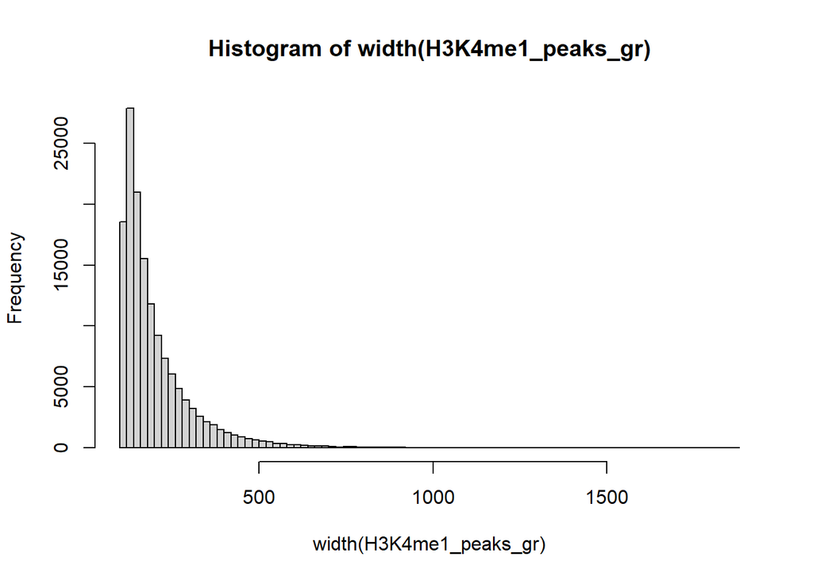

```r
hist(width(H3K4me1_peaks_gr), breaks=75) # here there are lots of small reads so will set minimum for very low number
```

```r
# Find overlaps between p300 and H3K4me1
overlap_H3K4me1_min <- findOverlaps(H3K4me1_peaks_gr, p300_peaks_gr, minoverlap = 5)

# Calculate percentage of p300 peaks that overlap with H3K4me1
percentage_H3K4me1_min <- length(unique(subjectHits(overlap_H3K4me1_min))) / length(p300_peaks_gr)*100
percentage_H3K4me1_min
```

```
## [1] 37.12995
```

```r
cat("Proportion of P300 peaks that overlap H3K4me1:", percentage_H3K4me1_min, "%\n")
```

```
## Proportion of P300 peaks that overlap H3K4me1: 37.12995 %
```

2. p300 and H3K27ac

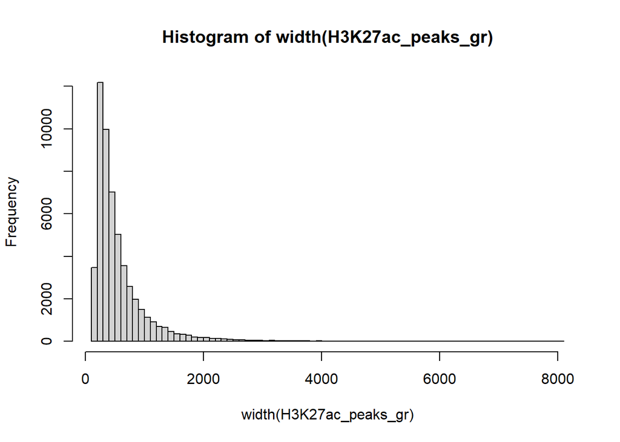

```r
hist(width(H3K27ac_peaks_gr), breaks=75) # there are many peaks around 300, so we can maybe set the minimum a bit higher again to 50
```

```r
# Find overlaps between p300 and H3K4me1
overlap_H3K27ac_min <- findOverlaps(H3K27ac_peaks_gr, p300_peaks_gr, minoverlap = 50)

# Calculate percentage of p300 peaks that overlap with H3K4me1
percentage_H3K27ac_min <- length(unique(subjectHits(overlap_H3K27ac_min))) / length(p300_peaks_gr)*100
percentage_H3K27ac_min
```

```
## [1] 45.97932
```

```r
cat("Proportion of P300 peaks that overlap H3K27ac:", percentage_H3K27ac_min, "%\n")
```

```
## Proportion of P300 peaks that overlap H3K27ac: 45.97932 %
```

3. p300 and H3K27me3

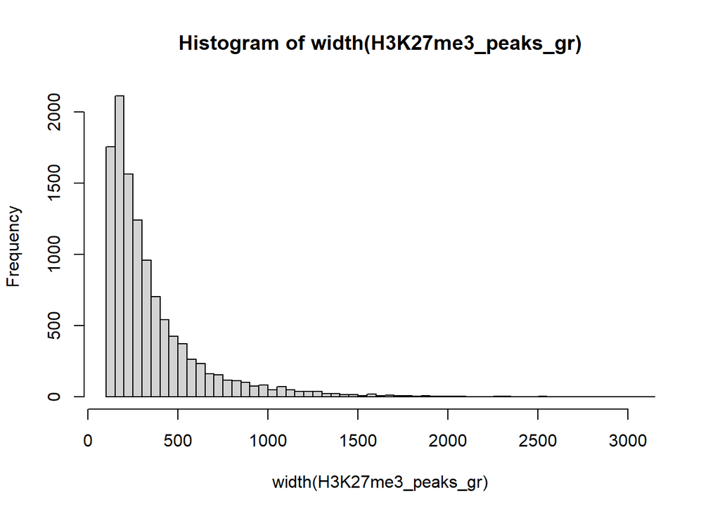

```r
hist(width(H3K27me3_peaks_gr), breaks=75) # many peaks around 200, so maybe we can set the minimum for 50 again
```

```r
# Find overlaps between p300 and H3K27me3
overlap_H3K27me3_min <- findOverlaps(H3K27me3_peaks_gr, p300_peaks_gr, minoverlap = 50)

# Calculate percentage of p300 peaks that overlap with H3K4me1
percentage_H3K27me3_min <- length(unique(subjectHits(overlap_H3K27me3_min))) / length(p300_peaks_gr)*100
percentage_H3K27me3_min
```

```
## [1] 0.1940651
```

```r
cat("Proportion of P300 peaks that overlap H3K27me3:", percentage_H3K27me3_min, "%\n")
```

```
## Proportion of P300 peaks that overlap H3K27me3: 0.1940651 %
```